# Taller 1 - Contingencias de vida

Anna Salazar y Joan Robles

Abril de 2026

# 1 Introducción

En este documento se calculan las primas de distintos seguros de vida y se elaboran algunas comparaciones.

Se emplean dos enfoques para calcular las primas: primero, se resuelve cada problema de forma analítica y se programa **una función por producto**; segundo, se programa una función con suficientes parámetros para calcular la prima de cualquier producto. Esta función calcula los valores esperados de forma explícita: vectorizando los componentes (descuento, pago y probabilidad) y resolviendo la sumatoria. Se hiceron pruebas unitarias para determinar que el resultado por ambas vías es el mismo.

Este proyecto se realizó en R y está disponible en el siguiente repositorio de Github: life_contingencies_unal

# 2 Datos y parámetros

- Tabla colombiana de mortalidad de asegurados 1998-2003. Extraída de la resolución 1555 DE 2010. Contiene información para edades desde los 15 hasta los 110 años.
- Tasa de crecimiento $r$ del valor asegurado de 5.1%, correspondiente a la inflación. Se define así para mantener el poder adquisitivo del valor asegurado.
- Tasa de interés técnica de 7.73%, correspondiente a la composición de interés real e inflación.
- La persona asegurada, con la que se evalúan los productos de la sección de funciones específicas, es una mujer de 60 años. Para los seguro temporales, la temporalidad base es 40 años. En la sección de resultados y comparaciones se evalúan otras edades y horizontes de cobertura.

```r
inflation <- 0.051
real_interest <- 0.025
# Ecuación de Fisher
nominal_interest <- (1 + inflation) * (1 + real_interest) - 1
print(round(nominal_interest * 100, 2))
```

```
## [1] 7.73
```

Otros parámetros y paquetes:

```r
# seed
seed <- 123
set.seed(seed)

# dependencies
source("general_functions.R")
source("life_ensurance.R")
source("specific_functions.R")

# for plotting
file_path <- file.path(getwd(), "res-1555-2010.pdf")
x_values <- 30:70
n_values <- 1:40

# baseline
m <- 12 # like months
gender <- "women"
age <- 60
base_n <- max(n_values)
```

Se emplea el paquete `pacman` para cargar paquetes e instalar lo que falte:

```r
# Install pacman if not available
if (!requireNamespace("pacman", quietly = TRUE)) {
  install.packages("pacman")
}

# Load (and install if needed) packages
pacman::p_load(
  dplyr,
  parallel,
  pdftools,
  plotly,
  ggplot2
)
```

# 3 Procesamiento de la tabla de mortalidad

La función process_mortality_table toma el texto bruto de la tabla de mortalidad y lo convierte en una tabla actuarial lista para valorar seguros. Primero identifica las filas numéricas del documento, limpia separadores, extrae los valores relevantes y conserva las columnas de edad y probabilidades anuales de muerte por sexo: $q_x^{(h)}$ y $q_x^{(m)}$.

Luego construye una tabla de vida con radix inicial de 100000 para hombres y mujeres. Para cada edad calcula el número esperado de fallecimientos y sobrevivientes mediante:

$$d_x = l_x q_x$$

$$l_{x+1} = l_x - d_x$$

Con la tasa de interés técnico
$$i$$
define el factor de descuento:

$$v = \frac{1}{1+i}$$

A partir de allí agrega las funciones de conmutación necesarias para valorar seguros:

$$D_x = l_x v^x$$

$$C_x = D_x v q_x = d_x
v^{x+1}$$

Después calcula las sumas acumuladas:

$$M_x = \sum_{k=x}^{\omega}
C_k$$

$$R_x = \sum_{k=x}^{\omega}
M_k$$

Estas magnitudes permiten obtener directamente primas únicas clásicas. En particular:

$$A_x = \frac{M_x}{D_x}$$

corresponde al seguro entero unitario, mientras que:

$$(IA)_x = \frac{R_x}{D_x}$$

corresponde al seguro entero con crecimiento aritmético del beneficio. Estas nuevas columnas se emplean en las funciones específicas definidas más adelante.

```r
# read mortality table
.mortality_file <- pdftools::pdf_text(file_path)[2]
mortality_table <- process_mortality_table(.mortality_file, nominal_interest) %>%
  as.data.frame()

# show
head(mortality_table, 10)
```

```
##    age    q_men  q_women   dx_men    lx_men dx_women  lx_women   Dx_men
## 1   15 0.000485 0.000272 48.50000 100000.00 27.20000 100000.00 32741.70
## 2   16 0.000496 0.000278 49.57594  99951.50 27.79244  99972.80 30378.34
## 3   17 0.000509 0.000285 50.85008  99901.92 28.48433  99945.01 28185.26
## 4   18 0.000523 0.000293 52.22211  99851.07 29.27554  99916.52 26150.16
## 5   19 0.000538 0.000302 53.69178  99798.85 30.16595  99887.25 24261.66
## 6   20 0.000554 0.000311 55.25882  99745.16 31.05555  99857.08 22509.21
## 7   21 0.000573 0.000322 57.12231  99689.90 32.14398  99826.03 20883.00
## 8   22 0.000593 0.000333 59.08224  99632.78 33.23136  99793.88 19373.92
## 9   23 0.000615 0.000345 61.23782  99573.70 34.41742  99760.65 17973.52
## 10  24 0.000639 0.000358 63.58846  99512.46 35.70199  99726.23 16673.99
##    Dx_women    Cx_men Cx_women   Mx_men Mx_women   Rx_men Rx_women     Ax_men
## 1  32741.70 14.740643 8.266917 628.2238 407.6064 22651.06 16652.47 0.01918727
## 2  30384.81 13.986824 7.841060 613.4832 399.3395 22022.83 16244.86 0.02019476
## 3  28197.41 13.317208 7.459805 599.4964 391.4984 21409.35 15845.53 0.02126986
```

[output cut: 18 more lines]

# 4 Productos

Antes de construir la función correspondiente a cada producto, se hizo una lista de todas las posibilidades. La lista corresponde a todas las combinaciones de parámetros de `get_premium_insurance`. Los parámetros son: La variable `frac_pay` indica si el pago del seguro se realiza de manera fraccionada (TRUE) o anual (FALSE). Por su parte, `frac_value` señala si el valor asegurado crece dentro del año (TRUE) o únicamente entre años (FALSE). El parámetro `growth` define la forma del crecimiento del beneficio, pudiendo ser aritmético (“arithmetic”) o geométrico (“geometric”). La variable `r_case` distingue entre ausencia de crecimiento (“zero”, cuando r = 0) y presencia de crecimiento (“nonzero”). Finalmente, `initial_payment` especifica si el esquema comienza en el nivel base (“a”) o incorpora el primer incremento desde el inicio (“b”). Cada combinación posible de estas características define un producto distinto, identificado de manera única mediante un índice.

```r
# read mortality table
case_table <- get_case_table()

# show
case_table
```

```
##    index frac_pay frac_value     growth  r_case initial_payment
## 1      1     TRUE       TRUE arithmetic    zero               a
## 2      2    FALSE       TRUE arithmetic    zero               a
## 3      3     TRUE      FALSE arithmetic    zero               a
## 4      4    FALSE      FALSE arithmetic    zero               a
## 5      5     TRUE       TRUE  geometric    zero               a
## 6      6    FALSE       TRUE  geometric    zero               a
## 7      7     TRUE      FALSE  geometric    zero               a
## 8      8    FALSE      FALSE  geometric    zero               a
## 9      9     TRUE       TRUE arithmetic nonzero               a
## 10    10    FALSE       TRUE arithmetic nonzero               a
## 11    11     TRUE      FALSE arithmetic nonzero               a
## 12    12    FALSE      FALSE arithmetic nonzero               a
## 13    13     TRUE       TRUE  geometric nonzero               a
## 14    14    FALSE       TRUE  geometric nonzero               a
```

[output cut: 18 more lines]

Por tanto, cada producto tiene un identificador y la función corrspondiente se nombra con este identificador. Por ejemplo, el producto del punto 1 corresponde a la combinación de parámetros 11 en la tabla de casos.

El resto de esta sección está dedicado a exhibir el desarrollo algebráico de cada producto y mostrar el uso de la función específica construida. Las funciones se prueban para los parámetros de la sección de parámetros. El usuario puede cambiar los parámetros y ejecutar nuevamente el *Markdown* para probarlo.

## 4.1 Punto 1

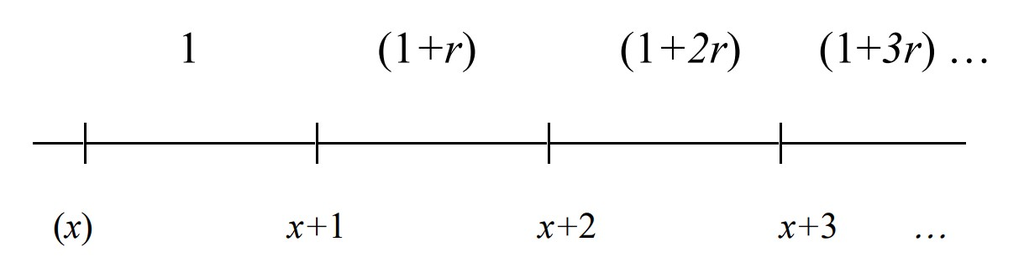

Prima de un seguro entero fraccionario con crecimiento del valor asegurado con patrón aritmético cada año. Para este punto se usa la función específica `price_case_11()` definida en `specific_functions.R`. El desarrollo algebráico es:

$$i^{(m)} = m\left((1+i)^{1/m}-1\right)$$

$$P_1 = \frac{i}{i^{(m)}}\left[A_x + r\left((IA)_x - A_x\right)\right]$$

$$P_1 = \frac{i}{i^{(m)}}\left[(1-r)A_x + r(IA)_x\right]$$

```r
premium_1 <- price_case_11(
  x = age,
  m = m,
  r = inflation,
  .mortality_file = .mortality_file,
  gender = gender,
  interest = nominal_interest
)

cat("Valor de la prima:", premium_1)
```

```
## Valor de la prima: 0.3467153
```

## 4.2 Punto 2

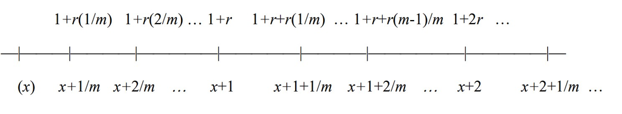

Prima de un seguro entero fraccionario con crecimiento del valor asegurado con patrón aritmético dentro de cada año. Para este punto se usa la función específica `price_case_25()` definida en `specific_functions.R`. El desarrollo algebráico es:

$$i^{(m)} = m\left((1+i)^{1/m}-1\right)$$

$$P_2
=
\frac{i}{i^{(m)}}\left[(1-r)A_x+r(IA)_x\right]
+
r\frac{i-i^{(m)}}{(i^{(m)})^2}A_x
+
\frac{r}{m}\frac{i}{i^{(m)}}A_x$$

$$P_2
=
\frac{i}{i^{(m)}}\left[(1-r)A_x+r(IA)_x\right]
+
r\left[
\frac{i-i^{(m)}}{(i^{(m)})^2}
+
\frac{i}{m i^{(m)}}
\right]A_x$$

```r
premium_2 <- price_case_25(
  x = age,
  m = m,
  r = inflation,
  .mortality_file = .mortality_file,
  gender = gender,
  interest = nominal_interest
)

cat("Valor de la prima:", premium_2)
```

```
## Valor de la prima: 0.3516009
```

## 4.3 Punto 3

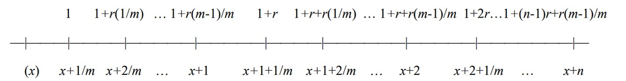

Prima de un seguro temporal fraccionario con crecimiento del valor asegurado con patrón aritmético dentro de cada año. La función específica de este punto está definida en `specific_functions.R` como `price_case_09_term()`. El desarrollo algebráico es:

$$i^{(m)} = m\left((1+i)^{1/m}-1\right)$$

$$A_{x:\overline{n}|}
=
\sum_{k=1}^{n} v^k \, {}_{k-1}p_x q_{x+k-1}$$

$$(IA)_{x:\overline{n}|}
=
\sum_{k=1}^{n} k v^k \, {}_{k-1}p_x q_{x+k-1}$$

$$P_3
=
\frac{i}{i^{(m)}}\left[(1-r)A_{x:\overline{n}|}
+
r(IA)_{x:\overline{n}|}\right]
+
r\frac{i-i^{(m)}}{(i^{(m)})^2}A_{x:\overline{n}|}$$

```r
premium_3 <- price_case_09_term(
  x = age,
  n = base_n,
  m = m,
  r = inflation,
  .mortality_file = .mortality_file,
  gender = gender,
  interest = nominal_interest
)

cat("Valor de la prima:", premium_3)
```

```
## Valor de la prima: 0.3415423
```

## 4.4 Punto 4

Prima de un seguro dotal, obtenido al agregar un seguro dotal puro al anterior. La función disponible en el repositorio para este punto está definida en `specific_functions.R` con el nombre `Problem4()`. El desarrollo algebráico es:

$${}_{n}E_x = v^n \, {}_np_x$$

$${}_{n}p_x
=
\prod_{j=0}^{n-1}(1-q_{x+j})$$

$$P_4
=
{}_{n}E_x + P_3$$

$$P_4
=
v^n\,{}_{n}p_x
+
\frac{i}{i^{(m)}}\left[(1-r)A_{x:\overline{n}|}
+
r(IA)_{x:\overline{n}|}\right]
+
r\frac{i-i^{(m)}}{(i^{(m)})^2}A_{x:\overline{n}|}$$

```r
premium_4 <- Problem4(
  x = age,
  m = m,
  r = inflation,
  n = base_n,
  .mortality_file = .mortality_file,
  gender = gender,
  interest = nominal_interest
)

cat("Valor de la prima:", premium_4)
```

```
## Valor de la prima: 0.3450673
```

## 4.5 Punto 5

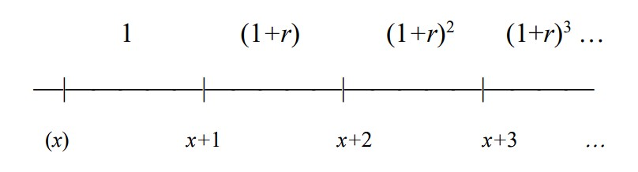

Prima de un seguro entero fraccionario con crecimiento del valor asegurado con patrón geométrico cada año. La función específica de este punto está definida en `specific_functions.R` como `price_case_15()`. El desarrollo algebráico es:

$$i^* = \frac{i-r}{1+r}$$

$$v^* = \frac{1}{1+i^*}
=
\frac{1+r}{1+i}$$

$$A_x(i^*)
=
\sum_{k=0}^{\omega-x} (v^*)^{k+1} \, {}_kp_x q_{x+k}$$

$$P_5
=
\frac{i}{i^{(m)}}\sum_{k=0}^{\omega-x}
(1+r)^k v^{k+1} \, {}_kp_x q_{x+k}$$

$$P_5
=
\frac{i}{i^{(m)}}\frac{1}{1+r}
\sum_{k=0}^{\omega-x}
(v^*)^{k+1} \, {}_kp_x q_{x+k}$$

$$P_5
=
\frac{i}{i^{(m)}}\frac{1}{1+r}A_x(i^*)$$

```r
premium_5 <- price_case_15(
  x = age,
  m = m,
  r = inflation,
  .mortality_file = .mortality_file,
  gender = gender,
  interest = nominal_interest
)

cat("Valor de la prima:", premium_5)
```

```
## Valor de la prima: 0.5143776
```

### 4.5.1 Comparación del crecimiento del valor asegurado: punto 2 vs punto 5

Se construye una gráfica para comparar el crecimiento del valor asegurado de los productos de los puntos 2 y 5.

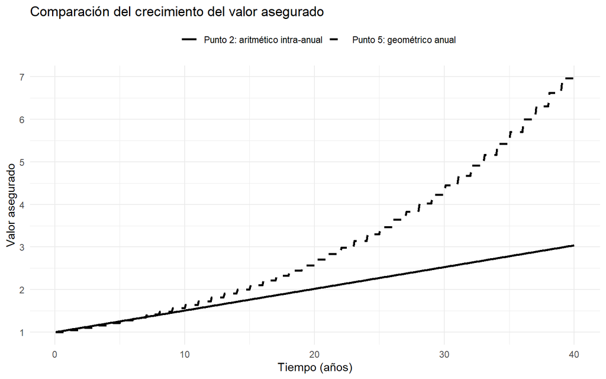

```r
plot_benefit_comparison(
  n_values = n_values,
  inflation = inflation,
  m = m
)
```

Evidentemente, el crecimiento geométrico es más rápido.

Además, se compara el valor de la prima única de los productos de los puntos 2 y 5 para la persona asegurada con los parámetros base y distintos plazos de asegurmaniento. Para ello se utiliza la función general `get_premium_insurance()`, por ser vectorizada, manteniendo en cada caso la estructura propia del producto.

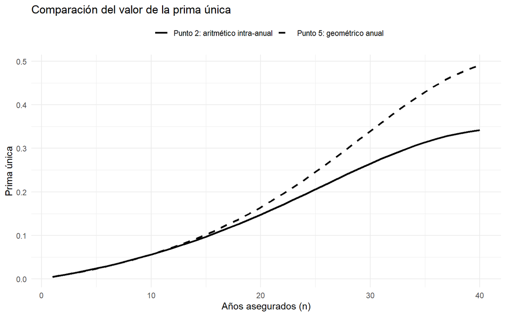

```r
plot_premium_comparison(
  n_values = n_values,
  age = age,
  mortality_file = .mortality_file,
  i = nominal_interest,
  r = inflation
)
```

Ambos productos se comportan muy similar al inicio, pero para plazos asegurados altos, el producto con crecimiento geométrico es mucho más costos que el de crecimiento aritmético.

# 5 Resultados comparados

En esta sección se comparan las primas únicas de los productos 1, 2, 3 y 5. Respectivamente: seguro entero fraccionario con crecimiento aritmético cada año, seguro entero fraccionario con crecimiento aritmético dentro de cada año, seguro temporal fraccionario con crecimiento aritmético dentro de cada año y seguro entero fraccionario con crecimiento geométrico cada año. Para ello se construyen tablas para un mismo plazo de cobertura (20 años) y mapas de calor sobre una grilla de edades y plazos; posteriormente se comparan los productos 2, 3 y 5 con el producto 1 (el base) a partir de sus diferencias de prima.

## 5.1 Tabla de resultados (mismo n)

Los resultados para diferentes edades son los siguientes:

```r
premium_table_5 <- build_table_all_ages(
  horizon_n = 20,
  mortality_file = .mortality_file,
  i = nominal_interest,
  r = inflation,
  m = m,
  gender = gender
)

premium_table_5
```

```
##    age producto_1 producto_2 producto_3 producto_4 producto_5
## 1   15      0.005      0.005      0.005      0.229      0.006
## 2   16      0.005      0.006      0.006      0.229      0.006
## 3   17      0.006      0.006      0.006      0.230      0.006
## 4   18      0.006      0.006      0.006      0.230      0.007
## 5   19      0.006      0.006      0.006      0.230      0.007
## 6   20      0.007      0.007      0.007      0.230      0.007
## 7   21      0.007      0.007      0.007      0.230      0.008
## 8   22      0.007      0.007      0.007      0.231      0.008
## 9   23      0.008      0.008      0.008      0.231      0.009
## 10  24      0.008      0.008      0.008      0.231      0.009
## 11  25      0.009      0.009      0.009      0.231      0.010
## 12  26      0.009      0.009      0.009      0.232      0.010
## 13  27      0.010      0.010      0.010      0.232      0.011
## 14  28      0.010      0.011      0.011      0.233      0.012
```

[output cut: 82 more lines]

## 5.2 Primas

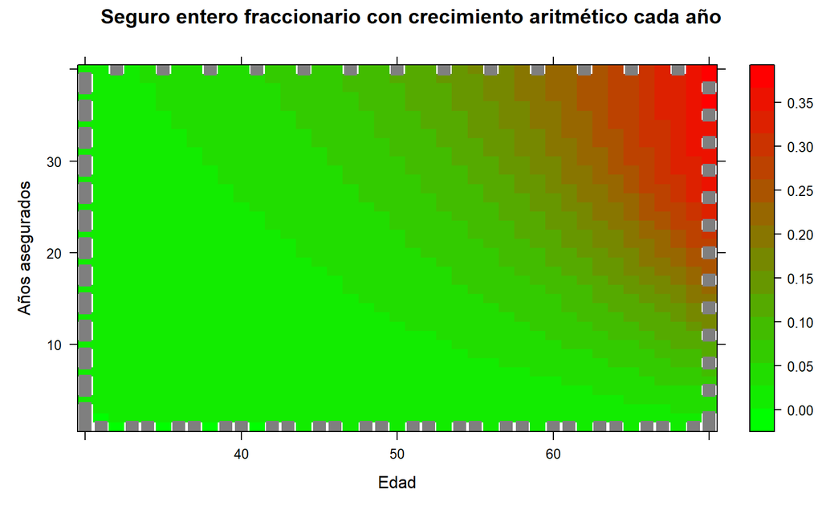

```r
premium_table_p1 <- evaluate_premium_grid(
  x_values = x_values,
  n_values = n_values,
  pricing_fun = get_premium_insurance,
  mortality_file = .mortality_file,
  i = 0.1,
  r = 0.05,
  frac_pay = TRUE,
  frac_value = FALSE,
  initial_payment = "a",
  growth = "arithmetic"
)

heatmap_xyz(
  x = premium_table_p1$x,
  y = premium_table_p1$y,
  z = premium_table_p1$z,
  xlab = "Edad",
  ylab = "Años asegurados",
  main = "Seguro entero fraccionario con crecimiento aritmético cada año"
)
```

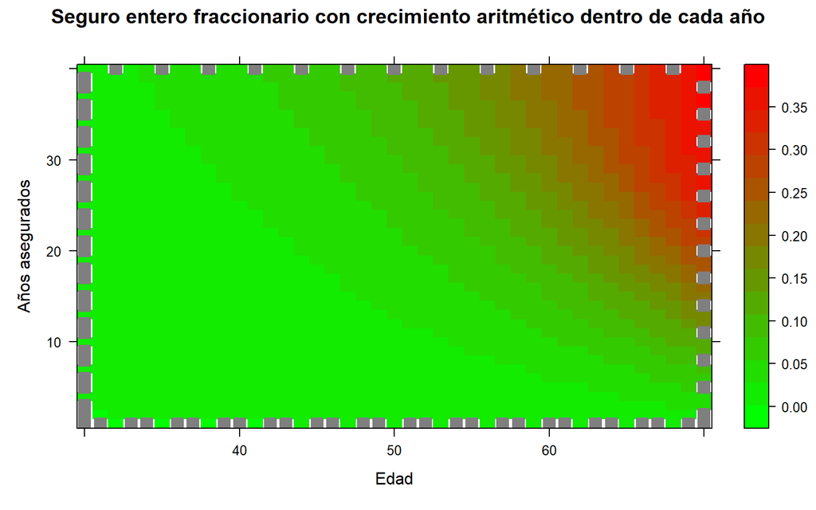

```r
premium_table_p2 <- evaluate_premium_grid(
  x_values = x_values,
  n_values = n_values,
  pricing_fun = get_premium_insurance,
  mortality_file = .mortality_file,
  i = 0.1,
  r = 0.05,
  frac_pay = TRUE,
  frac_value = TRUE,
  initial_payment = "b",
  growth = "arithmetic"
)

heatmap_xyz(
  x = premium_table_p2$x,
  y = premium_table_p2$y,
  z = premium_table_p2$z,
  xlab = "Edad",
  ylab = "Años asegurados",
  main = "Seguro entero fraccionario con crecimiento aritmético dentro de cada año"
)
```

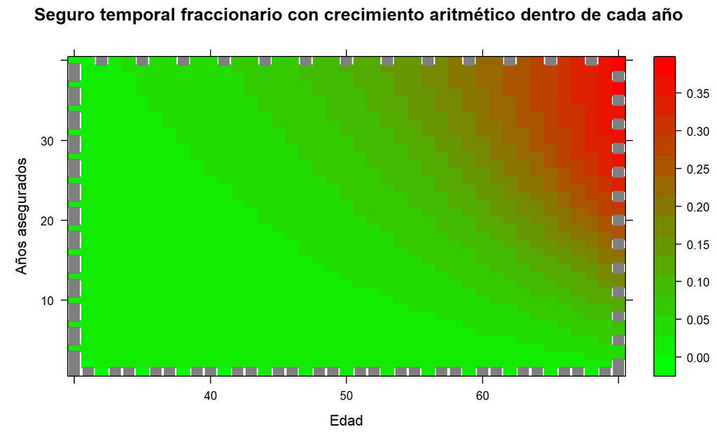

```r
premium_table_p3 <- evaluate_premium_grid(
  x_values = x_values,
  n_values = n_values,
  pricing_fun = get_premium_insurance,
  mortality_file = .mortality_file,
  gender = "women",
  i = 0.1,
  r = 0.05,
  frac_pay = TRUE,
  frac_value = TRUE,
  initial_payment = "a",
  growth = "arithmetic"
)

heatmap_xyz(
  x = premium_table_p3$x,
  y = premium_table_p3$y,
  z = premium_table_p3$z,
  xlab = "Edad",
  ylab = "Años asegurados",
  main = "Seguro temporal fraccionario con crecimiento aritmético dentro de cada año"
)
```

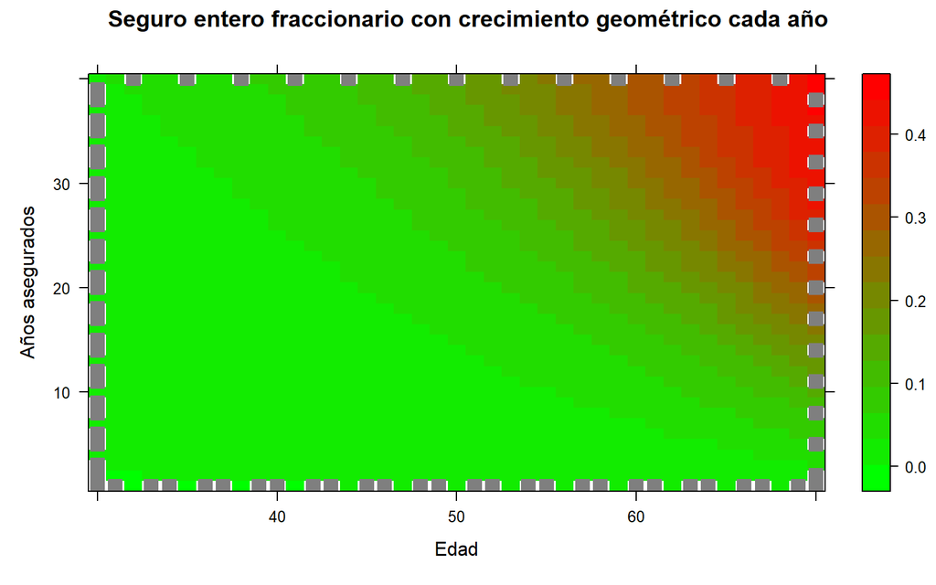

```r
premium_table_p5 <- evaluate_premium_grid(
  x_values = x_values,
  n_values = n_values,
  pricing_fun = get_premium_insurance,
  mortality_file = .mortality_file,
  i = 0.1,
  r = 0.05,
  frac_pay = TRUE,
  frac_value = FALSE,
  initial_payment = "a",
  growth = "geometric"
)

heatmap_xyz(
  x = premium_table_p5$x,
  y = premium_table_p5$y,
  z = premium_table_p5$z,
  xlab = "Edad",
  ylab = "Años asegurados",
  main = "Seguro entero fraccionario con crecimiento geométrico cada año"
)
```

Hay varias conclusiones:

- El valor de la prima crece con la edad.
- El valor de la prima crece con el número de años asegurados.
- Para personas de edad alta, hay un punto en el que incrementar el número de años asegurados no incrementa el valor de la prima, esto se debe a la edad terminal $w$. Por ejemplo, es lo mismo para una persona de 90 años comprar un seguro para 20 años o para 30: el riesgo cubierto es el mismo.
- La prima del seguro geométrico crece más rápido con los años asegurados que el caso aritmético, como se observó arriba para una edad específica.

## 5.3 Comparaciones

Para hacer las comparaciones se calculan las diferencias:

```r
diff_p2_p1 <- premium_table_p2
diff_p2_p1$z <- premium_table_p2$z - premium_table_p1$z

diff_p3_p1 <- premium_table_p3
diff_p3_p1$z <- premium_table_p3$z - premium_table_p1$z

diff_p5_p1 <- premium_table_p5
diff_p5_p1$z <- premium_table_p5$z - premium_table_p1$z
```

Y se obtienen los siguientes resultados:

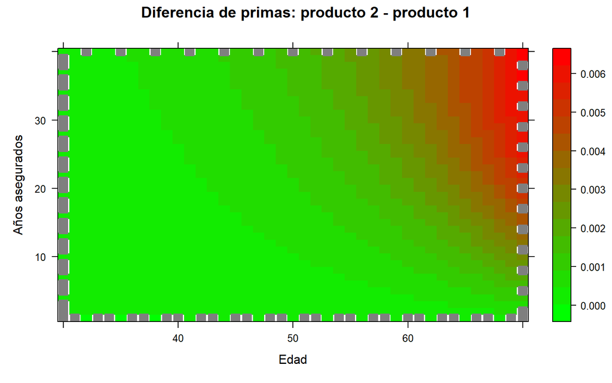

```r
heatmap_xyz(
  x = diff_p2_p1$x,
  y = diff_p2_p1$y,
  z = diff_p2_p1$z,
  xlab = "Edad",
  ylab = "Años asegurados",
  main = "Diferencia de primas: producto 2 - producto 1"
)
```

El seguro 2 es más caro porque el valor asegurado crece cada mes, no solo a final, así que el valor promedio es ligeramente mayor.

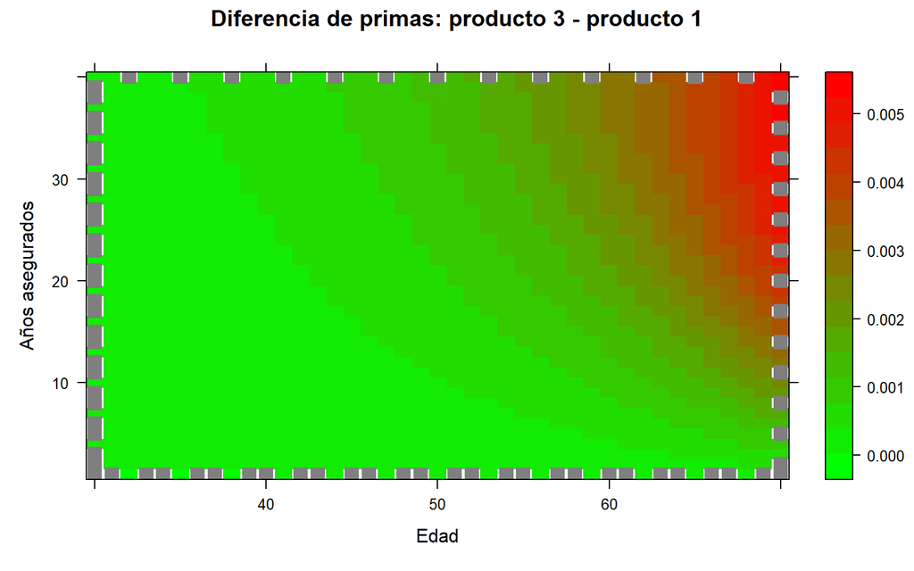

```r
heatmap_xyz(
  x = diff_p3_p1$x,
  y = diff_p3_p1$y,
  z = diff_p3_p1$z,
  xlab = "Edad",
  ylab = "Años asegurados",
  main = "Diferencia de primas: producto 3 - producto 1"
)
```

El seguro 3 es más caro por la misma razón. La diferencia radica en el pago inicial y es mínima.

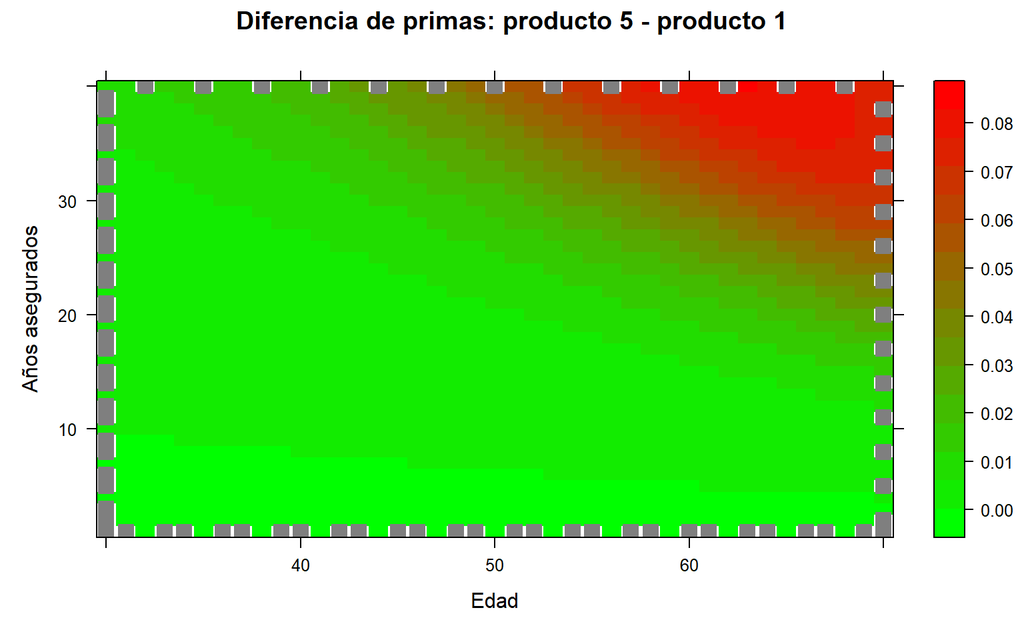

```r
heatmap_xyz(
  x = diff_p5_p1$x,
  y = diff_p5_p1$y,
  z = diff_p5_p1$z,
  xlab = "Edad",
  ylab = "Años asegurados",
  main = "Diferencia de primas: producto 5 - producto 1"
)
```

El seguro 5 es con diferencia el más caro, debido a su tipo de crecimiento. En particular, para personas de edad avanzada y alto número de años asegurados.

# 6 Organización del repositorio

Los archivos disponibles en el repositorio son:

- `general_functions.R`: procesamiento de la tabla de mortalidad y funciones auxiliares (construcción de $l_x$, $d_x$, funciones de conmutación, etc.).
- `life_ensurance.R`: motor general de pricing (`get_premium_insurance`) y lógica de enrutamiento hacia cada caso según parámetros.
- `specific_functions.R`: funciones con soluciones cerradas para casos particulares (por ejemplo, `price_case_11`, `price_case_25`, `price_case_09_term`, `price_case_15`).
- `general_graphs.R`: funciones para visualización (heatmaps, fancharts, comparaciones de primas y beneficios).
- `Taller_1.Rmd`: documento principal que explica los productos, ejecuta los cálculos y presenta comparaciones sin duplicar código.
- `playground.R`: archivo auxiliar para pruebas, debugging y experimentación fuera del flujo principal del taller.
- `instructions.pdf`: enunciado original del taller con la definición de los productos a valorar.
- `res-1555-2010.pdf`: tabla de mortalidad utilizada como base técnica para los cálculos actuariales.
- `plots/`: carpeta que contiene figuras de apoyo (esquemas de beneficios de cada producto incluidos en el documento).
- `.gitignore`: archivo de configuración para excluir archivos no relevantes del control de versiones (outputs, temporales, etc.).